# Final_Project

## Load featureCounts into R for downstream data analysis

### I next read the featureCounts txt summary into R for downstream data analysis.

```r
# Install necessary packages
library(tidyverse)
```

```r
library(ggplot2)
library(magrittr)
library(DESeq2)
library(pheatmap)

# Set the path to the directory containing the data

folder <- "~/Documents/ANGSD/count_table/" # Summary files from featurecounts run
readcounts <- paste0(folder, "featcounts_SHPRH.txt.summary") %>%
  read.table(., header=TRUE)
str(readcounts)
```

```
## 'data.frame':    12 obs. of  10 variables:
##  $ Status                                                       : chr  "Assigned" "Unassigned_Unmapped" "Unassigned_MappingQuality" "Unassigned_Chimera" ...
##  $ HEK293T_SHPRH_KO_2D10_1_aligned.Aligned.sortedByCoord.out.bam: int  40193937 0 0 0 0 0 5766495 0 0 3716328 ...
##  $ HEK293T_SHPRH_KO_2D10_2_aligned.Aligned.sortedByCoord.out.bam: int  42996236 0 0 0 0 0 6292887 0 0 3525433 ...
##  $ HEK293T_SHPRH_KO_2D10_3_aligned.Aligned.sortedByCoord.out.bam: int  41519944 0 0 0 0 0 5926369 0 0 3594288 ...
##  $ HEK293T_SHPRH_KO_2D9_1_aligned.Aligned.sortedByCoord.out.bam : int  38233609 0 0 0 0 0 5584444 0 0 3159589 ...
##  $ HEK293T_SHPRH_KO_2D9_2_aligned.Aligned.sortedByCoord.out.bam : int  36589353 0 0 0 0 0 5231365 0 0 3030132 ...
##  $ HEK293T_SHPRH_KO_2D9_3_aligned.Aligned.sortedByCoord.out.bam : int  44758883 0 0 0 0 0 6469175 0 0 3833895 ...
##  $ HEK293T_SHPRH_WT_2C11_1_aligned.Aligned.sortedByCoord.out.bam: int  42217698 0 0 0 0 0 6442261 0 0 3066771 ...
##  $ HEK293T_SHPRH_WT_2C11_2_aligned.Aligned.sortedByCoord.out.bam: int  38836270 0 0 0 0 0 5739483 0 0 3442355 ...
##  $ HEK293T_SHPRH_WT_2C11_3_aligned.Aligned.sortedByCoord.out.bam: int  35712546 0 0 0 0 0 5274562 0 0 2879235 ...
```

```r
## Convert sample names to more useful identifiers

orig_names <- names(readcounts)
names(readcounts) <- gsub(".*(WT_2C11|KO_2D9|KO_2D10)(_[0-9]+).*", "\\1\\2\\3", orig_names)
str(readcounts)
```

```
## 'data.frame':    12 obs. of  10 variables:
##  $ Status   : chr  "Assigned" "Unassigned_Unmapped" "Unassigned_MappingQuality" "Unassigned_Chimera" ...
##  $ KO_2D10_1: int  40193937 0 0 0 0 0 5766495 0 0 3716328 ...
##  $ KO_2D10_2: int  42996236 0 0 0 0 0 6292887 0 0 3525433 ...
##  $ KO_2D10_3: int  41519944 0 0 0 0 0 5926369 0 0 3594288 ...
##  $ KO_2D9_1 : int  38233609 0 0 0 0 0 5584444 0 0 3159589 ...
##  $ KO_2D9_2 : int  36589353 0 0 0 0 0 5231365 0 0 3030132 ...
##  $ KO_2D9_3 : int  44758883 0 0 0 0 0 6469175 0 0 3833895 ...
##  $ WT_2C11_1: int  42217698 0 0 0 0 0 6442261 0 0 3066771 ...
##  $ WT_2C11_2: int  38836270 0 0 0 0 0 5739483 0 0 3442355 ...
##  $ WT_2C11_3: int  35712546 0 0 0 0 0 5274562 0 0 2879235 ...
```

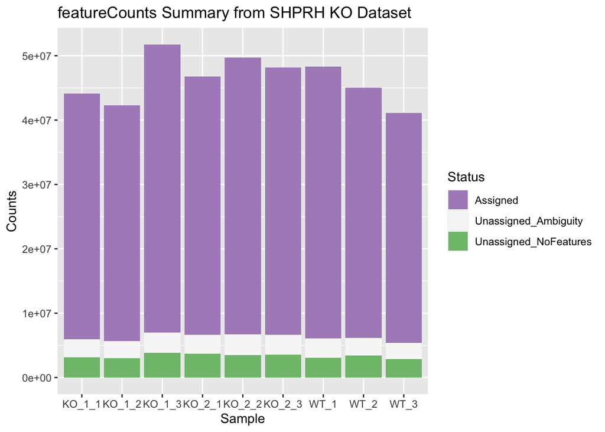

```r
# Data transformation and further altering of sample names

readcounts <- pivot_longer(readcounts, -1, names_to = "Sample", values_to = "Counts") %>%
  mutate(Sample=str_replace(Sample,"2D10","2")) %>%
  mutate(Sample=str_replace(Sample,"2D9","1")) %>%
  mutate(Sample=str_remove(Sample,"2C11_"))

# Bar plot of featureCounts

readcounts %>%
  filter(Status %in% c("Assigned", "Unassigned_NoFeatures", "Unassigned_Ambiguity")) %>%
  ggplot(mapping = aes(x = Sample, y = Counts, fill = Status)) +
    geom_bar(stat = "identity") +
    scale_fill_brewer(palette = "PRGn") +
    ggtitle("featureCounts Summary from SHPRH KO Dataset")
```

## Build DESeq data set

```r
# Set the path to the directory containing the count matrix
folder <- "~/Documents/ANGSD/count_table/" # Summary files from featurecounts run
readcounts <- paste0(folder, "featcounts_SHPRH.txt") %>%
  read.table(., header=TRUE)

# Convert sample names to more useful identifiers
orig_names <- names(readcounts)
names(readcounts) <- gsub(".*(WT_2C11|SHPRH_KO_2D9|SHPRH_KO_2D10)(_[0-9]+).*", "\\1\\2\\3", orig_names)
str(readcounts)
```

```
## 'data.frame':    60651 obs. of  15 variables:
##  $ Geneid         : chr  "ENSG00000223972.5" "ENSG00000227232.5" "ENSG00000278267.1" "ENSG00000243485.5" ...
##  $ Chr            : chr  "chr1;chr1;chr1;chr1;chr1;chr1;chr1;chr1;chr1" "chr1;chr1;chr1;chr1;chr1;chr1;chr1;chr1;chr1;chr1;chr1" "chr1" "chr1;chr1;chr1;chr1;chr1" ...
##  $ Start          : chr  "11869;12010;12179;12613;12613;12975;13221;13221;13453" "14404;15005;15796;16607;16858;17233;17606;17915;18268;24738;29534" "17369" "29554;30267;30564;30976;30976" ...
##  $ End            : chr  "12227;12057;12227;12721;12697;13052;14409;13374;13670" "14501;15038;15947;16765;17055;17368;17742;18061;18366;24891;29570" "17436" "30039;30667;30667;31109;31097" ...
##  $ Strand         : chr  "+;+;+;+;+;+;+;+;+" "-;-;-;-;-;-;-;-;-;-;-" "-" "+;+;+;+;+" ...
##  $ Length         : int  1735 1351 68 1021 138 1219 840 1414 2618 3726 ...
##  $ SHPRH_KO_2D10_1: int  1 10 4 2 0 0 0 0 0 0 ...
##  $ SHPRH_KO_2D10_2: int  0 48 8 2 0 0 0 0 0 0 ...
##  $ SHPRH_KO_2D10_3: int  0 38 5 2 0 0 0 0 0 0 ...
##  $ SHPRH_KO_2D9_1 : int  0 36 7 2 0 0 0 0 0 0 ...
##  $ SHPRH_KO_2D9_2 : int  0 47 8 0 0 0 0 0 0 0 ...
##  $ SHPRH_KO_2D9_3 : int  1 16 3 7 0 0 0 0 0 0 ...
##  $ WT_2C11_1      : int  0 38 10 3 0 0 0 0 0 0 ...
##  $ WT_2C11_2      : int  0 40 13 2 0 0 0 0 0 0 ...
##  $ WT_2C11_3      : int  0 29 11 0 0 0 0 0 0 0 ...
```

### Generate the DESeqDataSet

#### I will use DESeq2 to normalize the samples for differences in their sequencing depth and explore the data.

```r
## gene IDs should be stored as row.names
row.names(readcounts) <- make.names(readcounts$Geneid)
## exclude the columns without read counts (columns 1 to 6 contain additional ## info such as genomic coordinates)
readcounts <- readcounts[ , -c(1:6)]
sample_info <- DataFrame(condition = gsub("_[0-9]+", "", names(readcounts)), row.names = names(readcounts) )
sample_info
```

```
## DataFrame with 9 rows and 1 column
##                   condition
##                 <character>
## SHPRH_KO_2D10_1 SHPRH_KOD10
## SHPRH_KO_2D10_2 SHPRH_KOD10
## SHPRH_KO_2D10_3 SHPRH_KOD10
## SHPRH_KO_2D9_1   SHPRH_KOD9
## SHPRH_KO_2D9_2   SHPRH_KOD9
## SHPRH_KO_2D9_3   SHPRH_KOD9
## WT_2C11_1             WTC11
## WT_2C11_2             WTC11
## WT_2C11_3             WTC11
```

```r
dds <- DESeqDataSetFromMatrix(countData = readcounts,
                                   colData = sample_info,
                                   design = ~ condition)
dds <- DESeq(dds)
dds
```

```
## class: DESeqDataSet
## dim: 60651 9
## metadata(1): version
## assays(4): counts mu H cooks
## rownames(60651): ENSG00000223972.5 ENSG00000227232.5 ...
##   ENSG00000210195.2 ENSG00000210196.2
## rowData names(26): baseMean baseVar ... deviance maxCooks
## colnames(9): SHPRH_KO_2D10_1 SHPRH_KO_2D10_2 ... WT_2C11_2 WT_2C11_3
## colData names(2): condition sizeFactor
```

## rlog normalization

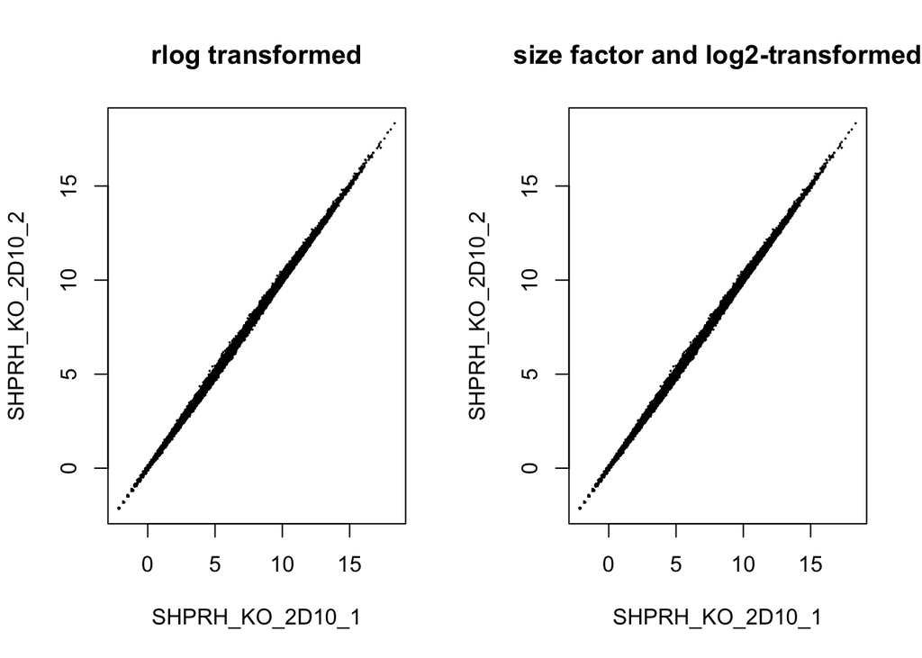

```r
rld <- rlog(dds, blind = TRUE)

## visually checking the results of the rlog function
par(mfrow=c(1,2))

## the rlog-transformed counts are stored in the accessor "assay"
plot(assay(rld)[,1],
     assay(rld)[,2],
     cex=.1, main = "rlog transformed",
     xlab = colnames(assay(rld[,1])),
     ylab = colnames(assay(rld[,2])) )

rlog.norm.counts <- assay(rld)

plot(rlog.norm.counts[,1:2], cex=.1,
     main = "size factor and log2-transformed")
```

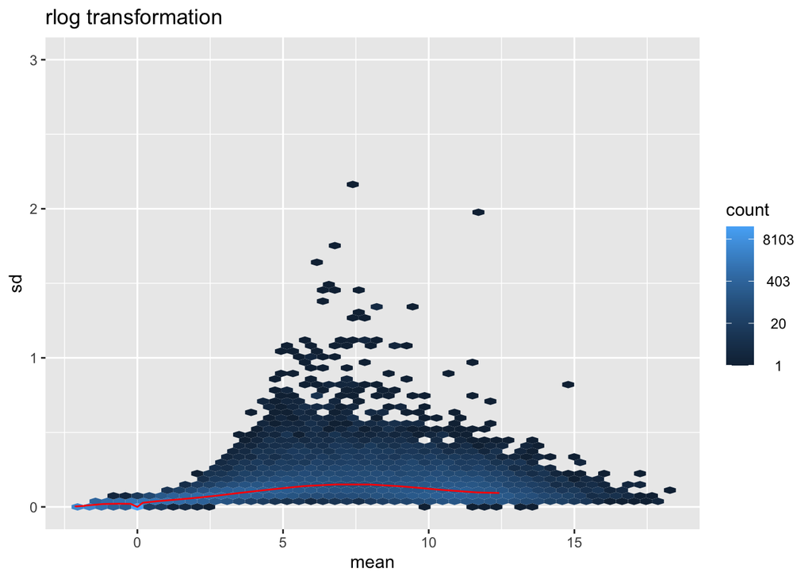

```r
## What does the mean-sd-plot show?

msd_plot <- vsn::meanSdPlot( rlog.norm.counts, ranks=FALSE, plot = FALSE)
msd_plot$gg + ggtitle("rlog transformation") + coord_cartesian(ylim = c(0,3))
```

```r
## Save objects on a disk to be loaded into future sessions
save.image(file = "RNAseqSHPRHKO.RData")
```

## Exploratory analyses

### I next performed exploratory analyses with the DESeq object and the rlog normalized matrix. This will provide insight into the clustering of the samples.

```r
# Load data
load("RNAseqSHPRHKO.RData")
ls()
```

```
## [1] "dds"              "folder"           "msd_plot"         "orig_names"
## [5] "readcounts"       "rld"              "rlog.norm.counts" "sample_info"
```

## Correlation coefficient clustering

### Correlation coefficients are used to observe the hierarchical clustering of the samples.

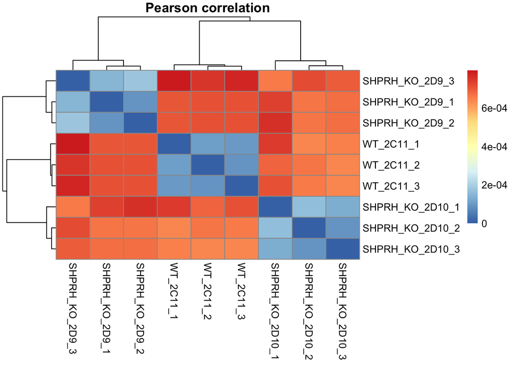

```r
corr_coeff <- cor(rlog.norm.counts, method = "pearson") # x is the rlog transformed counts, and method specifies the correlation coefficient
as.dist(1-corr_coeff, upper = TRUE) %>%
as.matrix %>%
pheatmap::pheatmap(., main = "Pearson correlation") # the as.dist function computes the distance in the correlation coefficients on the rlog transformed counts, piping this into the as.matrix function returns the distance matrix computed, and this is piped into the pheatmap function that draws a clustered heatmap
```

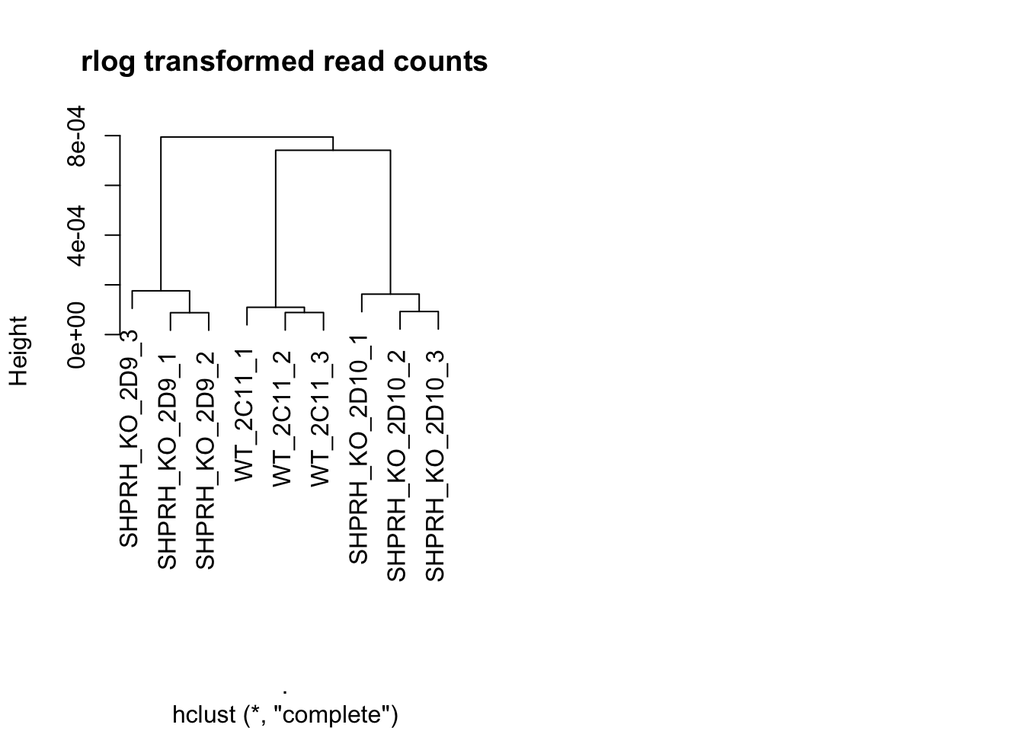

```r
# Comparing the effects of rlog
par(mfrow=c(1,2))
# Pearson corr. for rlog.norm values
as.dist(1 - corr_coeff) %>% hclust %>%
plot( ., labels = colnames(rlog.norm.counts),
main = "rlog transformed read counts") # the distances are clustered and plotted
```

## PCA

### Principal component analysis (PCA) is used to reduce the dimensionality of, or the number of variables in, the data. This is done by computing the principal components to subsequentally change the basis on the data. The dendrogram clustering showed efficient clustering of the sample groups, so I expect to see little variance between the triplicates for each sample.

```r
rv <- rowVars(assay(rld)) # rowVars(assay(DESeq.rlog)) is equivalent to rowVars(rlog.norm.counts); this function defines rv as variant estimates for each row in the matrix
top_variable <- order(rv, decreasing = TRUE)[seq_len(500)] # this defines top_variable as a permutation with the row variations in descending order
pca <- prcomp(t(assay(rld)[top_variable, ])) # this defines pca as the principal component analysis of the transposed rlog.norm.counts matrix, returning the object of class prcomp
head(pca$x)
```

```
##                       PC1       PC2        PC3         PC4          PC5
## SHPRH_KO_2D10_1 -5.244703 11.634982  1.5196714 -0.14700185  0.199586441
## SHPRH_KO_2D10_2 -5.308230 11.787621 -1.0181744 -0.05930652 -0.449898196
## SHPRH_KO_2D10_3 -5.399731 11.758241 -0.4897964  0.20980096  0.239599602
## SHPRH_KO_2D9_1  13.640662 -1.717584 -0.7161498  0.01924831 -0.735421059
## SHPRH_KO_2D9_2  13.586312 -1.565651 -0.9267305  0.32095317  0.750971459
## SHPRH_KO_2D9_3  13.701571 -1.532940  1.6269359 -0.33730627 -0.007344221
##                        PC6         PC7        PC8           PC9
## SHPRH_KO_2D10_1 -0.4260762  0.80097885  0.1619439  1.302680e-14
## SHPRH_KO_2D10_2 -0.2539757 -0.24058091 -0.9384151  1.393330e-14
## SHPRH_KO_2D10_3  0.6773164 -0.54954656  0.7812908  1.505453e-14
## SHPRH_KO_2D9_1   0.5633325  0.77604256  0.1627241  2.494532e-15
## SHPRH_KO_2D9_2  -0.8686827 -0.08961943  0.1882266  2.376571e-16
## SHPRH_KO_2D9_3   0.3099492 -0.68907296 -0.3499283 -1.344411e-15
```

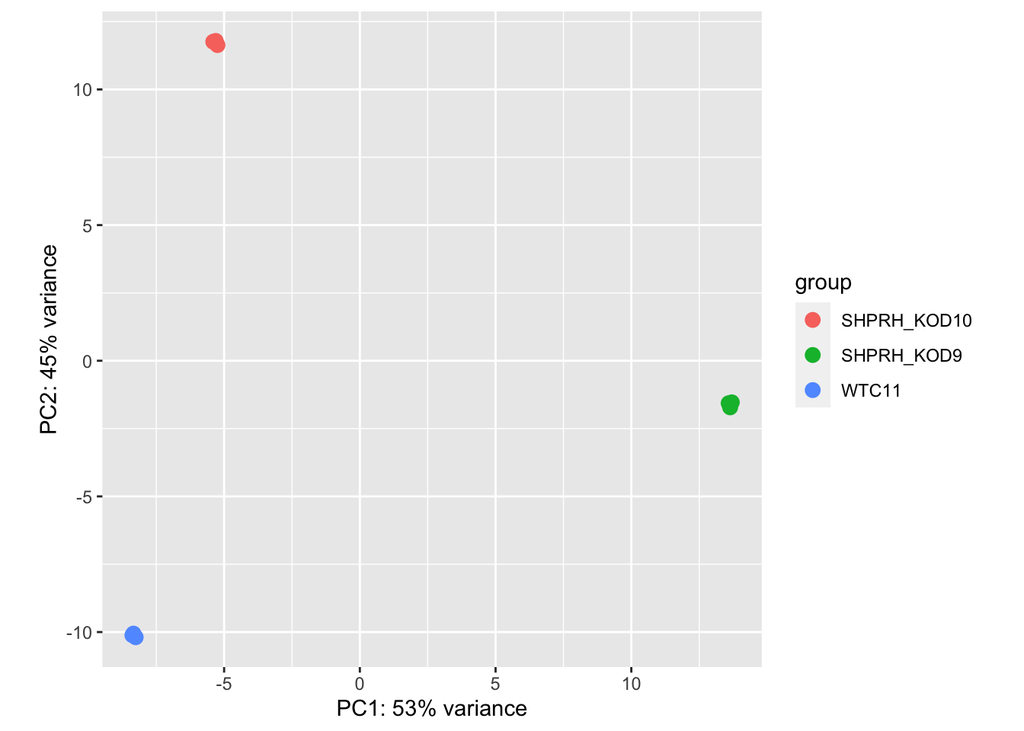

```r
plotPCA(rld)
```

## Differential gene expression

```r
# Extract the base means across samples
res <- results(dds, independentFiltering = TRUE, alpha = 0.05)
head(res)
```

```
## log2 fold change (MLE): condition WTC11 vs SHPRH KOD10
## Wald test p-value: condition WTC11 vs SHPRH KOD10
## DataFrame with 6 rows and 6 columns
##                    baseMean log2FoldChange     lfcSE      stat    pvalue
##                   <numeric>      <numeric> <numeric> <numeric> <numeric>
## ENSG00000223972.5  0.207518      -0.810850  4.080456 -0.198715 0.8424853
## ENSG00000227232.5 33.567544       0.313520  0.450271  0.696291 0.4862464
## ENSG00000278267.1  7.760264       1.158508  0.655020  1.768661 0.0769504
## ENSG00000243485.5  2.110002      -0.150174  1.362205 -0.110243 0.9122166
## ENSG00000284332.1  0.000000             NA        NA        NA        NA
## ENSG00000237613.2  0.000000             NA        NA        NA        NA
##                        padj
##                   <numeric>
## ENSG00000223972.5        NA
## ENSG00000227232.5  0.674898
## ENSG00000278267.1  0.181727
## ENSG00000243485.5        NA
## ENSG00000284332.1        NA
## ENSG00000237613.2        NA
```

```r
summary(res)
```

```
##
## out of 40912 with nonzero total read count
## adjusted p-value < 0.05
## LFC > 0 (up)       : 3772, 9.2%
## LFC < 0 (down)     : 3557, 8.7%
## outliers [1]       : 0, 0%
## low counts [2]     : 17780, 43%
## (mean count < 3)
## [1] see 'cooksCutoff' argument of ?results
## [2] see 'independentFiltering' argument of ?results
```

### How many reads have a padj < 0.05?

```r
table(res$padj < 0.05)
```

```
##
## FALSE  TRUE
## 15803  7329
```

### How many reads were sequenced for each sample?

```r
colSums(counts(dds))
```

```
## SHPRH_KO_2D10_1 SHPRH_KO_2D10_2 SHPRH_KO_2D10_3  SHPRH_KO_2D9_1  SHPRH_KO_2D9_2
##        40193937        42996236        41519944        38233609        36589353
##  SHPRH_KO_2D9_3       WT_2C11_1       WT_2C11_2       WT_2C11_3
##        44758883        42217698        38836270        35712546
```

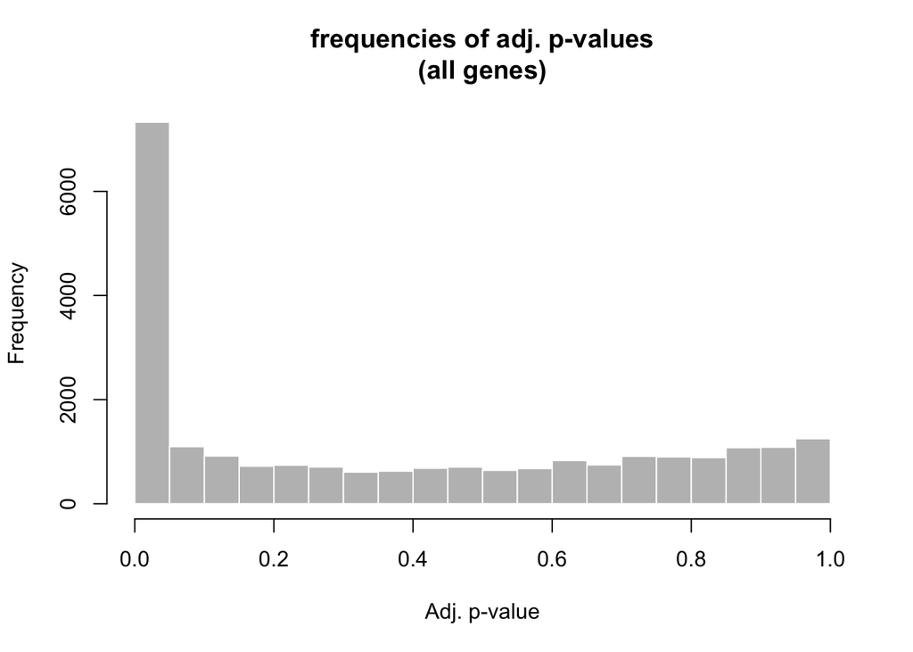

```r
# Histogram of adjusted p-values
hist(res$padj,
     col="grey", border="white", xlab="Adj. p-value", ylab="Frequency",
     main="frequencies of adj. p-values\n(all genes)",
     cex = 0.4)
```

```r
# Sorted table of the results, sorted by padj
resSorted <- res[order(res$padj),]
head(resSorted)
```

```
## log2 fold change (MLE): condition WTC11 vs SHPRH KOD10
## Wald test p-value: condition WTC11 vs SHPRH KOD10
## DataFrame with 6 rows and 6 columns
##                     baseMean log2FoldChange     lfcSE      stat       pvalue
##                    <numeric>      <numeric> <numeric> <numeric>    <numeric>
## ENSG00000101871.16  4735.146       -2.92334 0.0654684  -44.6526  0.00000e+00
## ENSG00000174460.4   1996.411       -3.09644 0.0740707  -41.8039  0.00000e+00
## ENSG00000009694.13  1151.162        3.75248 0.1077692   34.8196 1.23058e-265
## ENSG00000166501.14   609.003        3.56407 0.1089791   32.7042 1.36325e-234
## ENSG00000008394.13  1156.264       -2.50387 0.0869295  -28.8034 1.94438e-182
## ENSG00000118640.11   401.588       -4.13586 0.1436449  -28.7922 2.68218e-182
##                            padj
##                       <numeric>
## ENSG00000101871.16  0.00000e+00
## ENSG00000174460.4   0.00000e+00
## ENSG00000009694.13 9.48857e-262
## ENSG00000166501.14 7.88370e-231
## ENSG00000008394.13 8.99546e-179
## ENSG00000118640.11 1.03407e-178
```

### Heat maps

```
# Heatmap of DEG sorted by padj
# identify genes with the desired adjusted p-value cut-off
DGEgenes <- rownames(subset(resSorted, padj < 0.05))

# extract rlog-transformed values into a matrix
rld <- DESeq.rlog(DGEgenes) %>% assay

library(pheatmap)
# heatmap of DEG sorted by p.adjust
pheatmap(rld, scale="row",
         show_rownames = FALSE, main = "DGE (row-based z-score)")
```

## I don’t know why the above script isn’t working now, but I swear it worked before! This was what it looked like, and it’s actually an exact representation of Richard’s analysis. I don’t know why it got messed up. But in the interest of time, here it is.

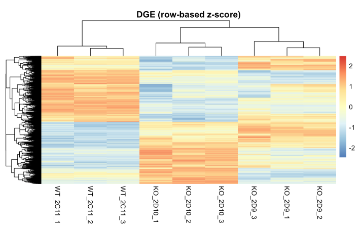

```r
knitr::include_graphics("/Users/ifehakano/Documents/ANGSD/z-score_HM.png")
```

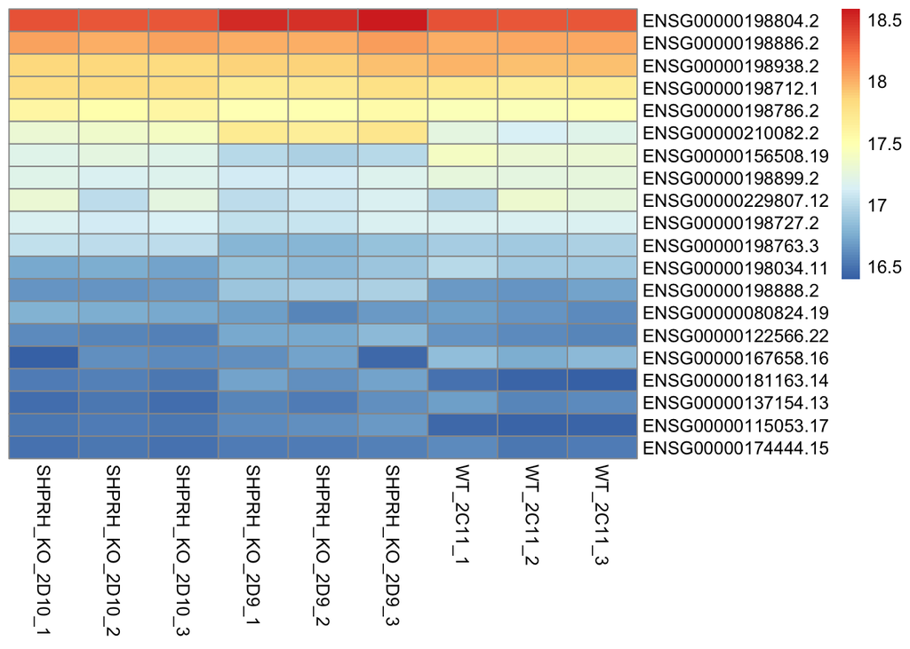

```r
# Heatmap of normalized row means
select <- order(rowMeans(counts(dds,normalized=FALSE)),
                decreasing=TRUE)[1:20]
rownames(dds) <- colnames(rld)
df <- NULL
pheatmap(assay(rld)[select,], cluster_rows=FALSE, show_rownames=TRUE, cluster_cols=FALSE, annotation_col=df)
```

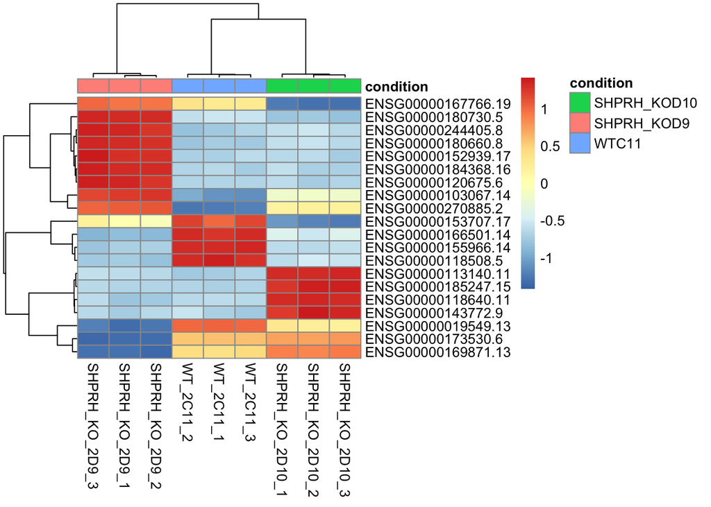

```r
# Heatmap for LFC
library("genefilter")
topVarianceGenes <- head(order(rowVars(assay(rld)), decreasing=T),20)
matrix <- assay(rld)[ topVarianceGenes, ]
matrix <- as.array(assay(rld)[ topVarianceGenes, ])
annotation_data <- as.data.frame(colData(rld)[c("condition")])
pheatmap(matrix, scale = 'row', annotation_col=annotation_data)
```

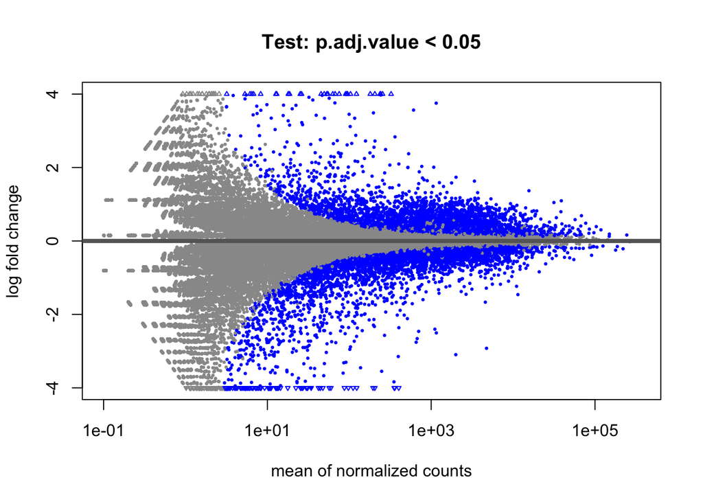

```r
plotMA(res, alpha = 0.05,main = "Test: p.adj.value < 0.05", ylim =c(-4,4))
```

# Discussion

## Issues with downstream data analysis in R studio

# Table of Generated Datasets

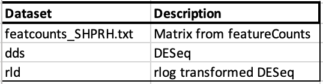

```r
knitr::include_graphics("/Users/ifehakano/Documents/ANGSD/datasets.png")
```

# References

### 1. Jenuwein T, Allis CD. Translating the histone code. Science. (2001)

### 2. Weake VM, Workman JL. Histone Ubiquitination: Triggering Gene Activity. Mol Cell. (2008)

### 3. Huang H, Sabari BR, Garcia BA, David Allis C, Zhao Y. SnapShot: Histone modifications. Cell. (2014)

### 4. Unk I, Hajdú I, Blastyák A, Haracska L. Role of yeast Rad5 and its human orthologs, HLTF and SHPRH in DNA damage tolerance. DNA Repair (Amst). (2010)

### 5. Lin J-R, Zeman MK, Chen J-Y, Yee M-C, Cimprich KA. SHPRH and HLTF Act in a Damage-specific Manner to Coordinate Different Forms of Post-replication Repair and Prevent Mutagenesis. Bone. (2012)

### 6. Brühl J, Trautwein J, Schäfer A, Linne U, Bouazoune K. The DNA repair protein SHPRH is a nucleosome-stimulated ATPase and a nucleosome-E3 ubiquitin ligase. Epigenetics and Chromatin. (2019)

### 7. Lee D, An J, Park YU, et al. SHPRH regulates rRNA transcription by recognizing the histone code in an mTOR-dependent manner. Proc Natl Acad Sci U S A. (2017)